# Лабораторная работа №4

## Общепринятые коммиты

Воспользуемся программой для помощи в форматировании коммитов (рис. 4).

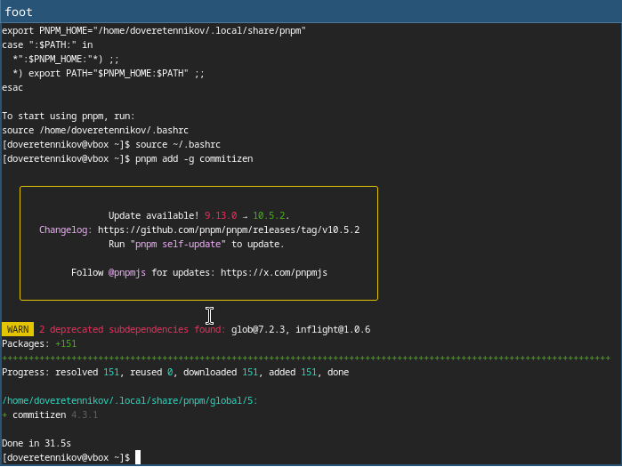

Программа

## Общепринятые коммиты

Воспользуемся программой для помощи в создании логов (рис. 5).

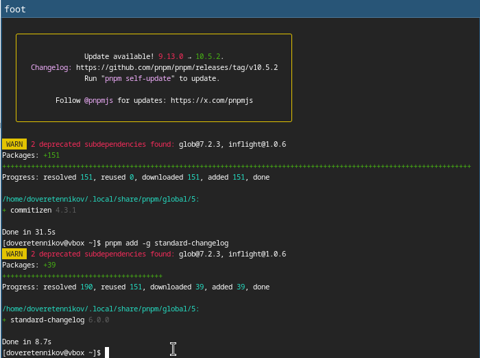

Программа

## Создание репозитория git

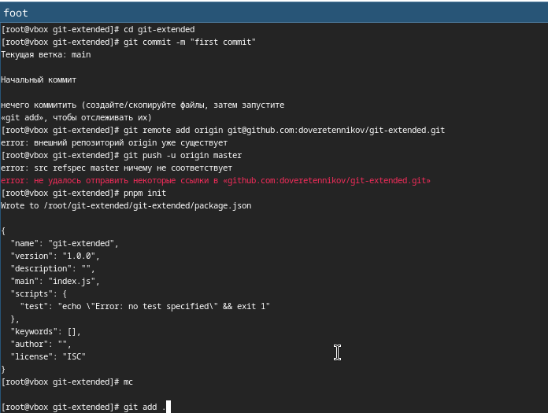

## Создание репозитория git

Сконфигурим формат коммитов. Для этого добавим в файл package.json команду для формирования коммитов (рис. 7).

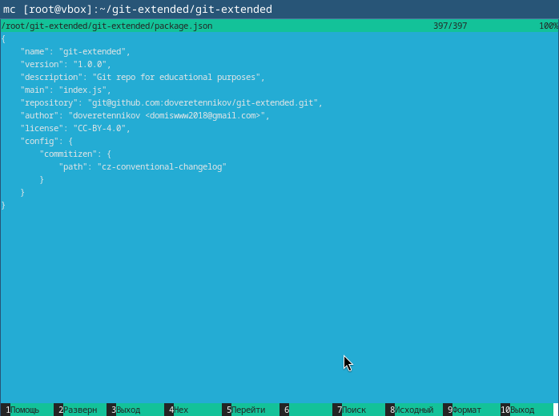

Исправленный файл package.json

## Создание репозитория git

Добавим новые файлы, выполним коммит, отправим на github (рис. 8).

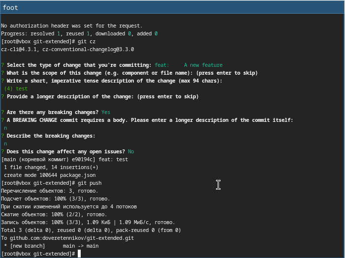

Выполнение коммита

## Создание репозитория git

Инициализируем git-flow (рис. 9).

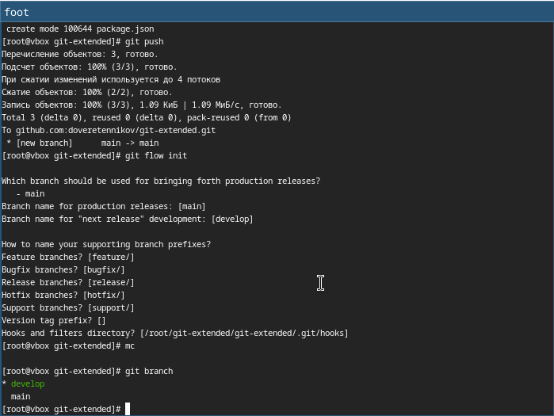

## Создание репозитория git

Загружаем весь репозиторий в хранилище, установим внешнюю ветку как вышестоящую для этой ветки, создадим релиз с версией 1.0.0 (рис. 10).

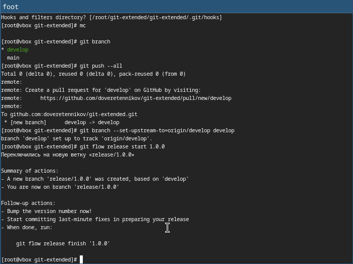

Загрузка репозитория, создание релиза

## Создание репозитория git

Создаем журнал изменений, добавляем журнал изменений в индекс, заливаем релизную ветку в основную ветку (рис. 11).

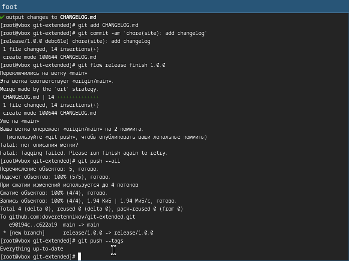

Создание журнала, добавление журнала, залитие релизной ветки

## Работа с репозиторием git

Создаем ветку для новой функциональности, по окончании разработки новой функциональности объединяем ветку feature_branch c develop (рис. 12).

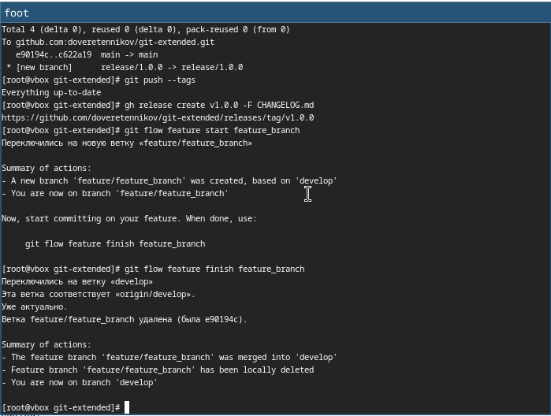

Создаем и объединяем ветки

## Работа с репозиторием git

Обновите номер версии в файле package.json. Установите её в 1.2.3 (рис. 13).

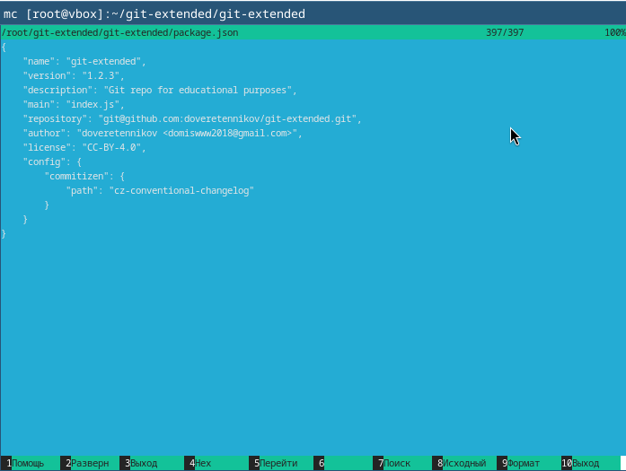

Обновленный номер версии в файле

## Работа с репозиторием git

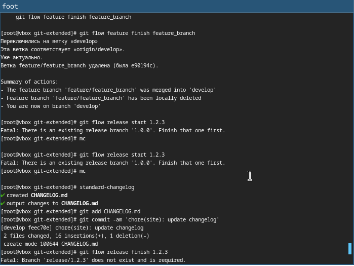

## Работа с репозиторием git

Добавляем журнал изменений в индекс, заливаем релизную ветку в основную ветку (рис. 15).

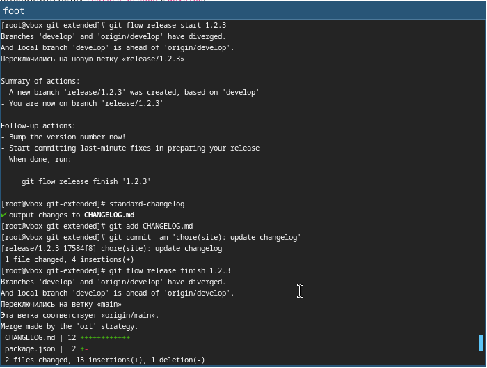

Создание релиза, создание журнала

## Работа с репозиторием git

Отправляем данные на Github (рис. 16).

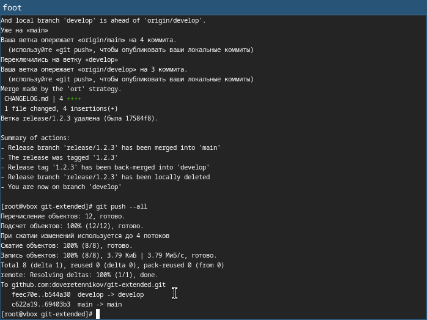

Отправка данных на Github

# Результаты

## Выводы

После выполнения данной лабораторной работы я получил навыки правильной работы с репозиториями git.

# Список литературы

- Курс Архитектура компьютеров и операционные системы. Раздел “Операционные системы” Лабораторная работа № 4 ТУИС РУДН.